```python
import pandas as pd
import seaborn as sns

# use the dataset for the plotting
archive_master=pd.read_csv('twitter_archive_master.csv')

# we only need images of dogs
indices=archive_master[archive_master.retweeted_status.isna()==False].index
archive_master.drop(indices,inplace=True)
```

### HARINASANDRATRA Lahatra Fitiavana

# 🚀 Data Wrangling using WeRateDogs datasets 🚀

*The study is about working with data about tweets about dogs that were rated by WeRateDogs.*

## Data wrangling

During the data wrangling. We found eight quality issues :

1. `twitter archive enhanced` some irrelevant values in column name ( like **incredibly**, **a**, **O** )
2. `twitter archive enhanced` irrelevant datatypes **retweeted_status_timestamp** **timestamp** should be datetime
3. `twitter archive enhanced` mistakes on dog ratings for observations on indices 313, 342, 433, 784, 902, 1068, 1120, 1165, 1202, 1228, 1254, 1274, 1351, 1433, 1598, 1634, 1635, 1662, 1663, 1779, 1843
4. `twitter_archive_enhanced` the dogs corresponding to these indices 191, 200, 460, 531, 565, 575, 705, 733, 778, 822, 889, 956, 1063, 1113 appear in more than one category
5. `tweet_json` ambiguous column name **id_str**.
6. `tweet_json` erroneous datatype for **lang** , should be categorical
7. `tweet_json` **possibly_sensitive**, **possibly_sensitive_appealable** should be boolean instead of float
8. `image prediction` contains image of other things than dog

Two tidiness issues:

1. `twitter archive enhanced` rating should be one single variabe
2. `2 datasets` are enough, `tweet_json`, `twitter_archive_enhanced` can be merged since they are about the same observation

## Analysis

#### 1. Observe the strength of relationship between the dog ratings, retweets, favorites :

Here we can see , that the number of retweets and favorites are highly correlated.

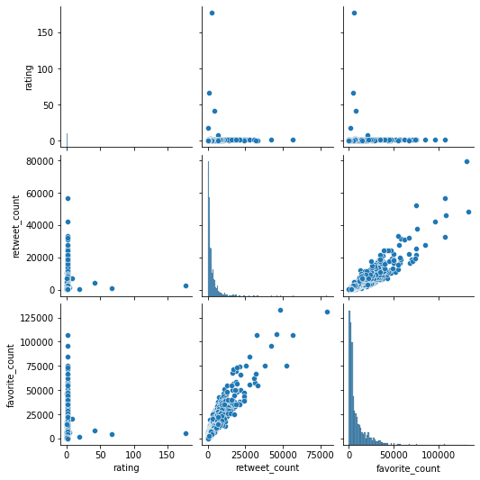

```python
sns.pairplot(archive_master, vars=["rating", "retweet_count", "favorite_count"]);
```

## Visualization

And finally, we visualize which day of the week get the tweets the most retweeted (`retweet_count` vs `tweet_day`)

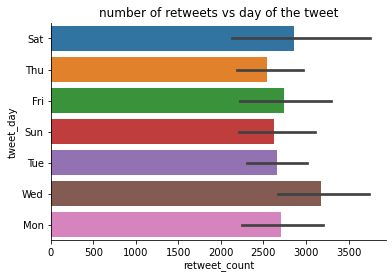

```python
archive_master['created_at']=pd.to_datetime(archive_master['created_at'])
archive_master['tweet_day']=archive_master['created_at'].dt.strftime("%a")
sorted_res=archive_master.sort_values('retweet_count')
graph=sns.barplot(y='tweet_day',x='retweet_count',data=sorted_res).set(title='number of retweets vs day of the tweet')
sns.despine()
```